# Homework 2

Sandra Matlievska

20.05.2023

# 1 Data Visualisation - Exploration

Now that you’ve demonstrated your software is setup, and you have the basics of data manipulation, the goal of this assignment is to practice transforming, visualising, and exploring data.

# 2 Mass shootings in the US

In July 2012, in the aftermath of a mass shooting in a movie theater in Aurora, Colorado, [Mother Jones](https://www.motherjones.com/politics/2012/07/mass-shootings-map/) published a report on mass shootings in the United States since 1982. Importantly, they provided the underlying data set as [an open-source database](https://www.motherjones.com/politics/2012/12/mass-shootings-mother-jones-full-data/) for anyone interested in studying and understanding this criminal behavior.

## 2.1 Obtain the data

```
## Rows: 125
## Columns: 14
## $ case                 <chr> "Oxford High School shooting", "San Jose VTA shoo…
## $ year                 <dbl> 2021, 2021, 2021, 2021, 2021, 2021, 2020, 2020, 2…
## $ month                <chr> "Nov", "May", "Apr", "Mar", "Mar", "Mar", "Mar", …
## $ day                  <dbl> 30, 26, 15, 31, 22, 16, 16, 26, 10, 6, 31, 4, 3, …
## $ location             <chr> "Oxford, Michigan", "San Jose, California", "Indi…
## $ summary              <chr> "Ethan Crumbley, a 15-year-old student at Oxford …
## $ fatalities           <dbl> 4, 9, 8, 4, 10, 8, 4, 5, 4, 3, 7, 9, 22, 3, 12, 5…
## $ injured              <dbl> 7, 0, 7, 1, 0, 1, 0, 0, 3, 8, 25, 27, 26, 12, 4, …
## $ total_victims        <dbl> 11, 9, 15, 5, 10, 9, 4, 5, 7, 11, 32, 36, 48, 15,…
## $ location_type        <chr> "School", "Workplace", "Workplace", "Workplace", …
## $ male                 <lgl> TRUE, TRUE, TRUE, TRUE, TRUE, TRUE, TRUE, TRUE, T…
## $ age_of_shooter       <dbl> 15, 57, 19, NA, 21, 21, 31, 51, NA, NA, 36, 24, 2…
## $ race                 <chr> NA, NA, "White", NA, NA, "White", NA, "Black", "B…
## $ prior_mental_illness <chr> NA, "Yes", "Yes", NA, "Yes", NA, NA, NA, NA, NA, …
```

| column(variable) | description |
| --- | --- |
| case | short name of incident |
| year, month, day | year, month, day in which the shooting occurred |
| location | city and state where the shooting occcurred |
| summary | brief description of the incident |
| fatalities | Number of fatalities in the incident, excluding the shooter |
| injured | Number of injured, non-fatal victims in the incident, excluding the shooter |
| total_victims | number of total victims in the incident, excluding the shooter |
| location_type | generic location in which the shooting took place |
| male | logical value, indicating whether the shooter was male |
| age_of_shooter | age of the shooter when the incident occured |
| race | race of the shooter |
| prior_mental_illness | did the shooter show evidence of mental illness prior to the incident? |

## 2.2 Explore the data

### 2.2.1 Specific questions

- Generate a data frame that summarizes the number of mass shootings per year.

```r
#In order to create a data frame that summarizes the number of mass shootings per year I grouped by year, and counted the frequency each year in the dataframe.

mass_shootings_peryear <- mass_shootings %>%
  group_by(year) %>%
  count(year)

#Generate a bar chart that identifies the number of mass shooters associated with each race category. The bars should be sorted from highest to lowest and each bar should show its number.
```

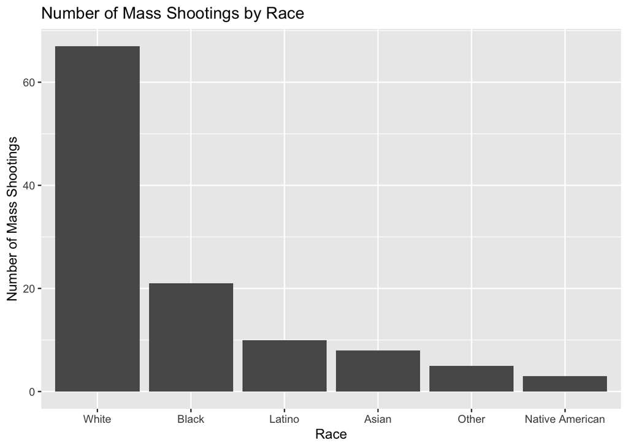

```r
#In order to create a bar chart that identifies the number of mass shooters associated with each race I counted the frequency of different races in the dataframe, and reordered the race column to create a new column sorted from the highest to lowest number of mass shooters, filtering out any NAs.

mass_shootings_byrace <- mass_shootings %>%
  count(race) %>%
  mutate(race = reorder(race, -n)) %>%
  filter(!is.na(race))

#Then I graphed the data in a bar graph, and labeled it with labs.

ggplot(mass_shootings_byrace)+
  aes(x = race, y = n)+
  geom_bar(stat = "Identity")+
  labs(title = "Number of Mass Shootings by Race", x="Race", y="Number of Mass Shootings")
```

- Generate a boxplot visualizing the number of total victims, by type of location.

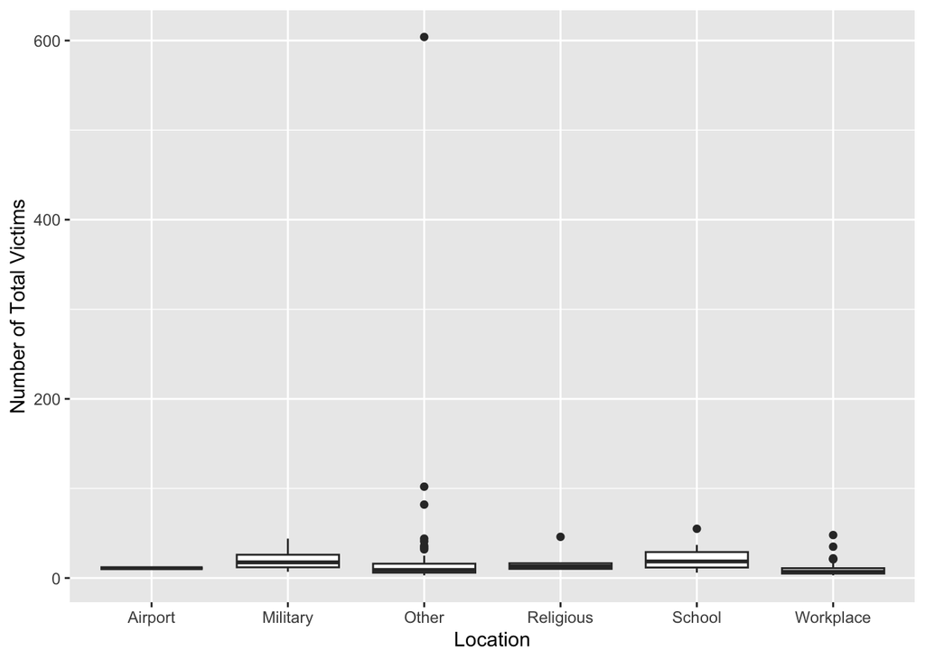

```r
#In order to create a boxplot visualizing the number of total victims, by type of location, I grouped by location type, and selected the relevant columns.

total_victims <- mass_shootings %>%
  group_by(location_type) %>%
  select(location_type, total_victims)

#Then I graphed the data in a boxplot, and labeled it with labs.

ggplot(total_victims)+
  aes(location_type, total_victims)+
  geom_boxplot()+
  labs(Title = "Number of Total Victims by Location", x = "Location", y = "Number of Total Victims")
```

- Redraw the same plot, but remove the Las Vegas Strip massacre from the dataset.

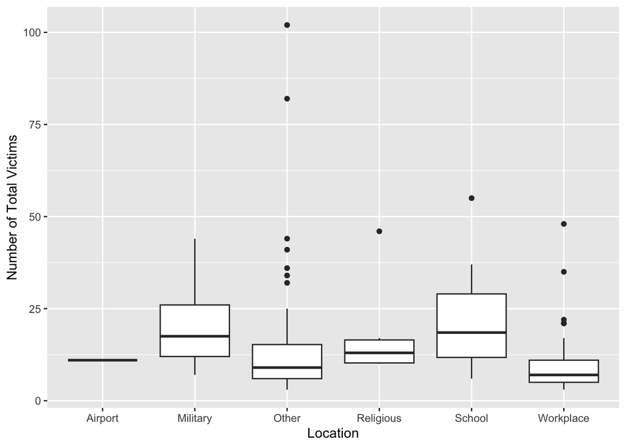

```r
#In order to remove the Las Vegas Strip massacre from the dataset, I simply filtered to exclude any data from cases that exceeded the second highest total victims with 102 total victims, aka excluding only the Las Vegas Strip massacre which was an outlier in our dataframe.

total_victims_minusvegas <- mass_shootings %>%
  filter(total_victims <= 102) %>%
  group_by(location_type) %>%
  select(location_type, total_victims)

#Then I graphed the data in a boxplot, and labeled it with labs.

ggplot(total_victims_minusvegas)+
  aes(location_type, total_victims)+
  geom_boxplot()+
  labs(Title = "Number of Total Victims by Location", x = "Location", y = "Number of Total Victims")
```

### 2.2.2 More open-ended questions

Address the following questions. Generate appropriate figures/tables to support your conclusions.

- How many white males with prior signs of mental illness initiated a mass shooting after 2000?

```r
#For Q1, I created a table, and filtered for cases with men as the shooters, cases where the shooters had prior mental illness, where the shooter's race was white, and the the cases after 2000.

q1 <- mass_shootings %>%
  filter(male == TRUE) %>%
  filter(prior_mental_illness == "Yes") %>%
  filter(race == "White") %>%
  filter(year > 2000) %>%

#Then using the count function to see the frequency of male in the dataframe, which enabled me to essentially count the number of cases that fit all of my criteria.

  count(male)

#Thus, there were 22 incidents that fit within the criteria.
```

- Which month of the year has the most mass shootings? Generate a bar chart sorted in chronological (natural) order (Jan-Feb-Mar- etc) to provide evidence of your answer.

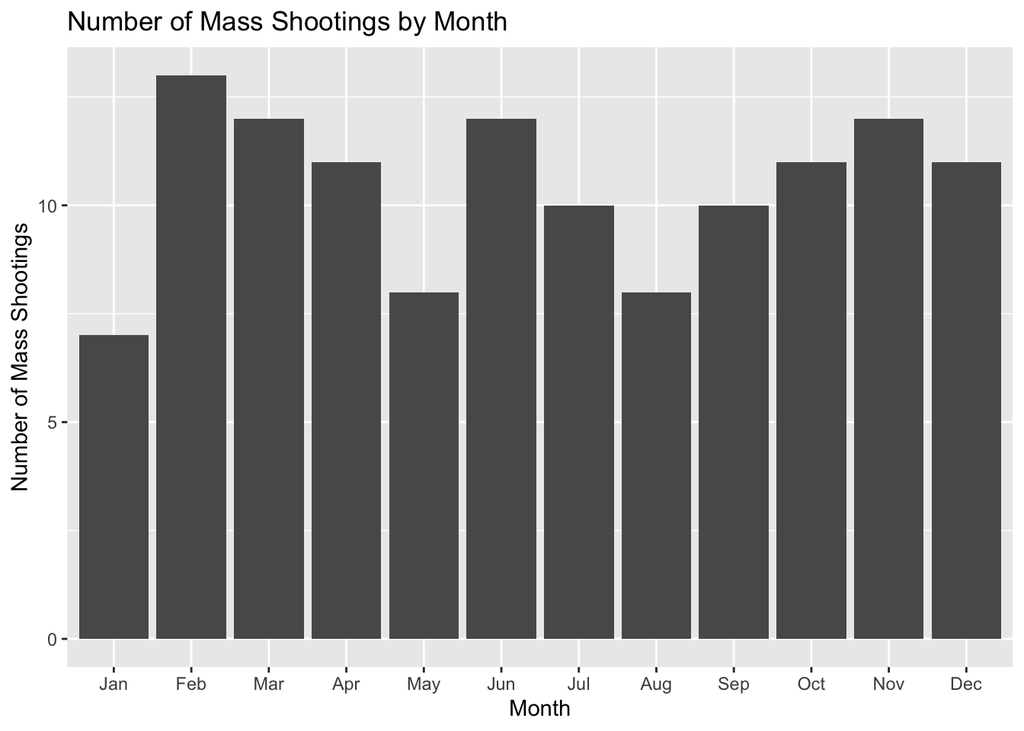

```r
#For Q2, I created a table, and counted the frequency of month in the data to see the number of cases in each month.

q2 <- mass_shootings %>%
  count(month)

#Then I graphed the data in a bar graph, and labeled it with labs. I also used scale_x_discrete to organize the months in the chronological/natural order.

ggplot(q2)+
  aes(x=month, y=n)+
  geom_bar(stat = "Identity")+
  labs(title = "Number of Mass Shootings by Month", x="Month", y="Number of Mass Shootings")+
  scale_x_discrete(limits = month.abb)
```

- How does the distribution of mass shooting fatalities differ between White and Black shooters? What about White and Latino shooters?

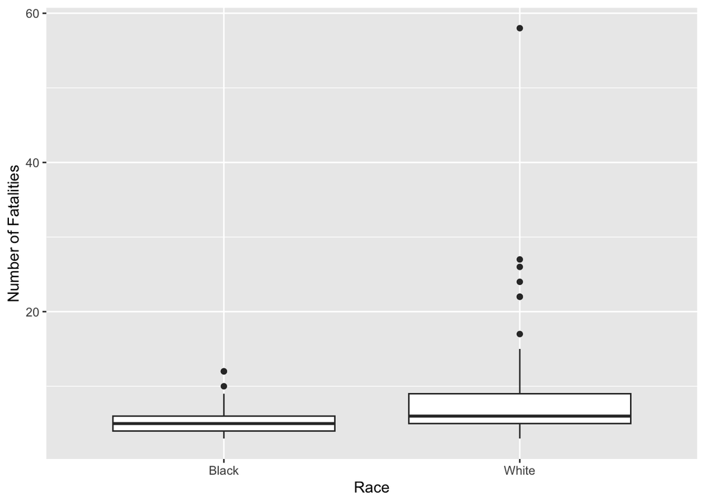

```r
#For Q3, I first created a table to assess the distribution of mass shooting fatalities by white and black shooters. I filtered the race column only for "White" and "Black", then I removed NAs in the race and fatalities columns, selected only the two relevant columns, and grouped by race.

q3a <- mass_shootings %>%
  filter(race %in% c("White", "Black")) %>%
  filter(!is.na (race)) %>%
  filter(!is.na (fatalities)) %>%
  select(race, fatalities) %>%
  group_by(race)

#Then I graphed the data in a box plot, and labeled it with labs.

ggplot(q3a)+
  aes(x=race, y=fatalities) +
  geom_boxplot() +
  labs(Title = "Distribution of Mass Shooting Fatalities by Race", x = "Race", y = "Number of Fatalities")
```

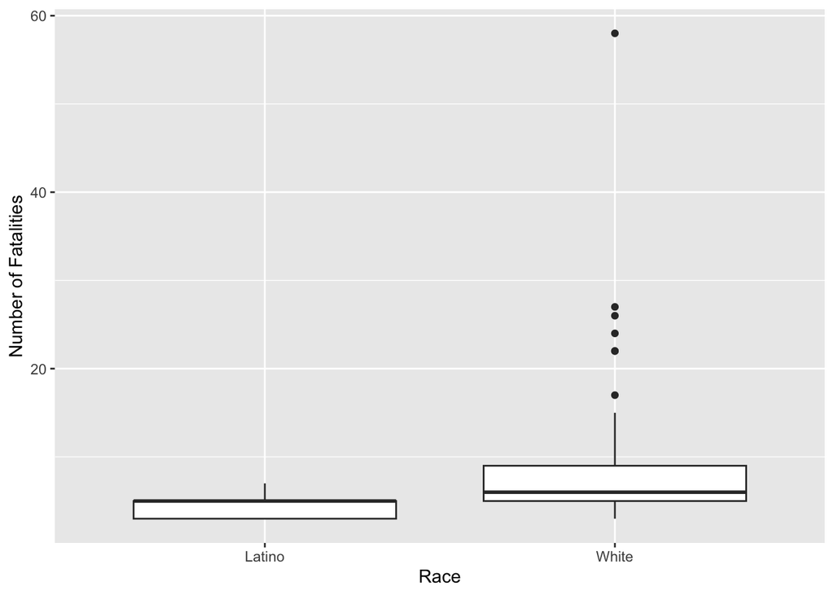

```r
#Then, I  created a table to assess the distribution of mass shooting fatalities by white and latino shooters. I filtered the race column only for "White" and "Latino", then I removed NAs in the race and fatalities columns, selected only the two relevant columns, and grouped by race.

q3b <- mass_shootings %>%
  filter(race %in% c("White", "Latino")) %>%
  filter(!is.na (race)) %>%
  filter(!is.na (fatalities)) %>%
  select(race, fatalities) %>%
  group_by(race)

#Then I graphed the data in a box plot, and labeled it with labs.

ggplot(q3b)+
  aes(x=race, y=fatalities) +
  geom_boxplot() +
  labs(Title = "Distribution of Mass Shooting Fatalities by Race", x = "Race", y = "Number of Fatalities")
```

### 2.2.3 Very open-ended

- Are mass shootings with shooters suffering from mental illness different from mass shootings with no signs of mental illness in the shooter?

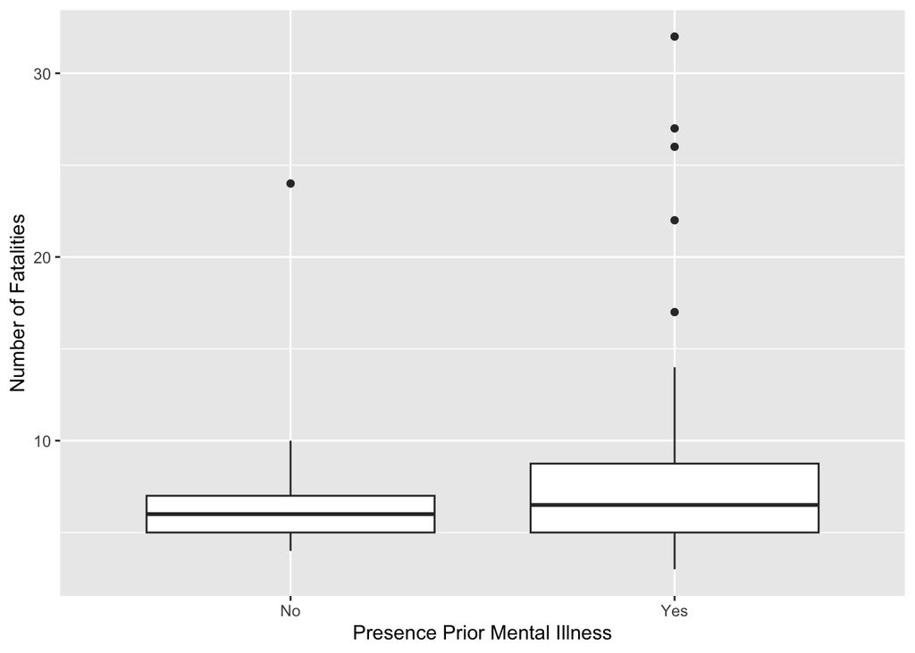

```r
#To evaluate whether mass shootings with shooters suffering from mental illness different from mass shootings with no signs of mental illness in the shooter, I first compared the fatalities between the two groups. I filtered out the NAs in the prior mental illness column, grouped by the category, and selected the two relevant columns.

q4a <- mass_shootings %>%
  filter(!is.na(prior_mental_illness)) %>%
  group_by(prior_mental_illness) %>%
  select(prior_mental_illness, fatalities)

#Then I graphed the data in a box plot, and labeled it with labs.

ggplot(q4a)+
  aes(x=prior_mental_illness, y=fatalities) +
  geom_boxplot() +
  labs(Title = "Distribution of Mass Shooting Fatalities by Prior Mental Illness", x = "Presence Prior Mental Illness", y = "Number of Fatalities")
```

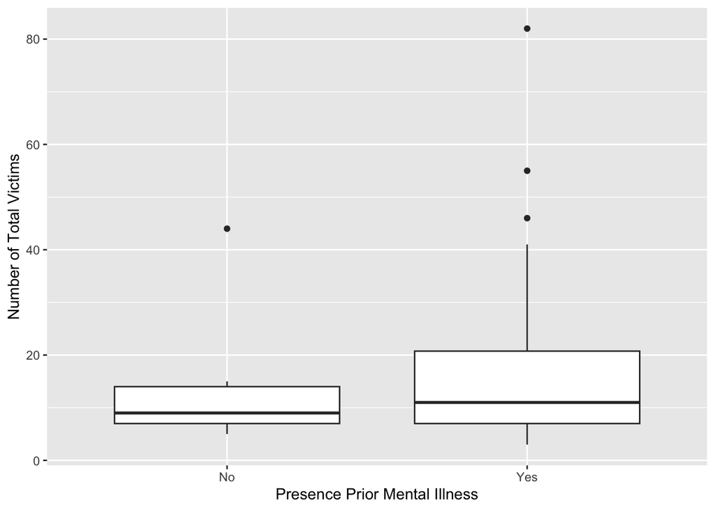

```r
#From the boxplots I can see that on average the number of fatalities is slightly higher in the cases where the shooter had signs of mental illness prior. There also tend to be more large outliers in number of fatalities.

#Then I compared the total victims between the two groups. I filtered out the NAs in the prior mental illness column, grouped by the category, and selected the two relevant columns.

q4b <- mass_shootings %>%
  filter(!is.na(prior_mental_illness)) %>%
  group_by(prior_mental_illness) %>%
  select(prior_mental_illness, total_victims)

#Then I graphed the data in a box plot, and labeled it with labs.

ggplot(q4b)+
  aes(x=prior_mental_illness, y=total_victims) +
  geom_boxplot() +
  labs(Title = "Distribution of Total Victims by Prior Mental Illness", x = "Presence Prior Mental Illness", y = "Number of Total Victims")
```

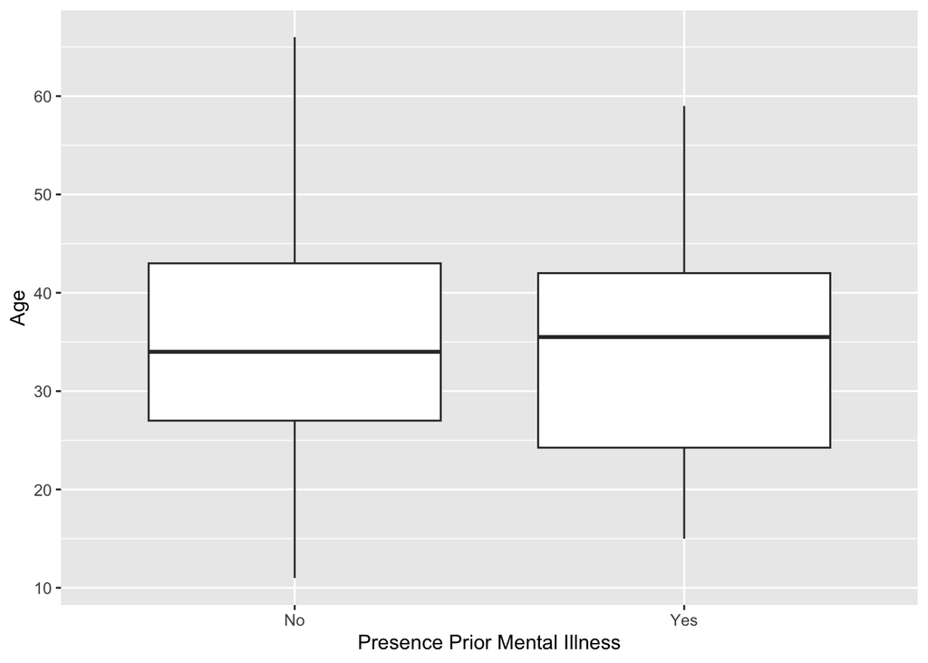

```r
#Similarly, the boxplot showed that on average the number of total victims is slightly higher in the cases where the shooter had signs of mental illness prior, with a larger upper quartile. There are also  more large outliers in number of total victims for shooters with signs of prior mental illness.

#Then I  compared the age of the shooters between the two groups. I filtered out the NAs in the prior mental illness column, grouped by the category, and selected the two relevant columns.

q4c <- mass_shootings %>%
  filter(!is.na(prior_mental_illness)) %>%
  group_by(prior_mental_illness) %>%
  select(prior_mental_illness, age_of_shooter)

#Then I graphed the data in a box plot, and labeled it with labs.

ggplot(q4c)+
  aes(x=prior_mental_illness, y=age_of_shooter) +
  geom_boxplot() +
  labs(Title = "Distribution of Age by Prior Mental Illness", x = "Presence Prior Mental Illness", y = "Age")
```

```r
#Lastly, the boxplot shows that the averages and range of the shooters between both categories are quite similar, with those with prior mental illness having a larger lower quartile.
```

- Assess the relationship between mental illness and total victims, mental illness and location type, and the intersection of all three variables.

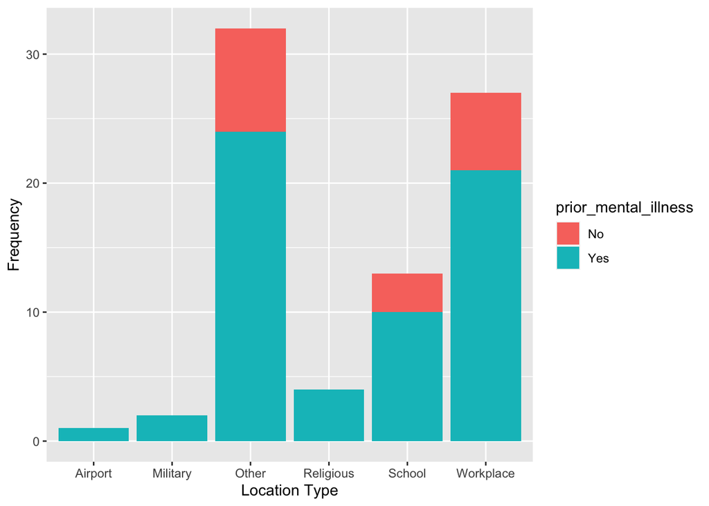

```r
#For Q5, to assess location type differences, I created a table selecting the relevant columns, removing NAs, and grouping by prior mental illness. I also counted frequency of location types.


q5a <- mass_shootings %>%
  filter(!is.na(prior_mental_illness)) %>%
  group_by(prior_mental_illness) %>%
  count(location_type)

#Then I graphed the data to show the differences in a bar graph, and labeled it with labs.

ggplot(q5a)+
  aes(x=location_type, y=n, fill=prior_mental_illness)+
  geom_col() +
  labs(Title = "Location Type Frequency by Prior Mental Illness", x = "Location Type", y = "Frequency")
```

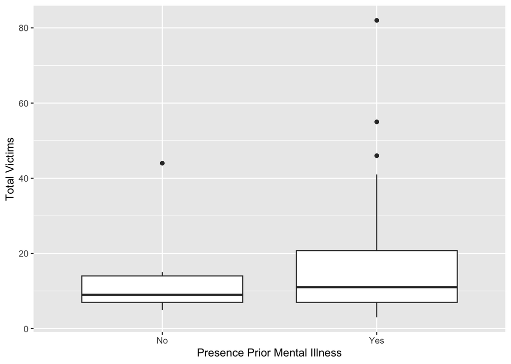

```r
#To assess total victims differences, I created a table selecting the relevant columns, removing NAs, and grouping by prior mental illness.

q5b <- mass_shootings %>%
  filter(!is.na(prior_mental_illness)) %>%
  group_by(prior_mental_illness) %>%
  select(total_victims, prior_mental_illness)

#Then I graphed the data to show the differences in a box plot, and labeled it with labs.

ggplot(q5b)+
  aes(x=prior_mental_illness, y=total_victims)+
  geom_boxplot()+
  labs(Title = "Distribution of Total Victims by Prior Mental Illness", x = "Presence Prior Mental Illness", y = "Total Victims")
```

Make sure to provide a couple of sentences of written interpretation of your tables/figures. Graphs and tables alone will not be sufficient to answer this question.

# 3 Exploring credit card fraud

We will be using a dataset with credit card transactions containing legitimate and fraud transactions. Fraud is typically well below 1% of all transactions, so a naive model that predicts that all transactions are legitimate and not fraudulent would have an accuracy of well over 99%– pretty good, no? (well, not quite as we will see later in the course)

You can read more on credit card fraud on [Credit Card Fraud Detection Using Weighted Support Vector Machine](https://www.scirp.org/journal/paperinformation.aspx?paperid=105944)

The dataset we will use consists of credit card transactions and it includes information about each transaction including customer details, the merchant and category of purchase, and whether or not the transaction was a fraud.

## 3.1 Obtain the data

The dataset is too large to be hosted on Canvas or Github, so please download it from dropbox https://www.dropbox.com/sh/q1yk8mmnbbrzavl/AAAxzRtIhag9Nc_hODafGV2ka?dl=0 and save it in your `dsb` repo, under the `data` folder

```
## Rows: 671,028
## Columns: 14
## $ trans_date_trans_time <dttm> 2019-02-22 07:32:58, 2019-02-16 15:07:20, 2019-…
## $ trans_year            <dbl> 2019, 2019, 2019, 2019, 2019, 2019, 2019, 2020, …
## $ category              <chr> "entertainment", "kids_pets", "personal_care", "…
## $ amt                   <dbl> 7.79, 3.89, 8.43, 40.00, 54.04, 95.61, 64.95, 3.…
## $ city                  <chr> "Veedersburg", "Holloway", "Arnold", "Apison", "…
## $ state                 <chr> "IN", "OH", "MO", "TN", "CO", "GA", "MN", "AL", …
## $ lat                   <dbl> 40.1186, 40.0113, 38.4305, 35.0149, 39.4584, 32.…
## $ long                  <dbl> -87.2602, -80.9701, -90.3870, -85.0164, -106.385…
## $ city_pop              <dbl> 4049, 128, 35439, 3730, 277, 1841, 136, 190178, …
## $ job                   <chr> "Development worker, community", "Child psychoth…
## $ dob                   <date> 1959-10-19, 1946-04-03, 1985-03-31, 1991-01-28,…
## $ merch_lat             <dbl> 39.41679, 39.74585, 37.73078, 34.53277, 39.95244…
## $ merch_long            <dbl> -87.52619, -81.52477, -91.36875, -84.10676, -106…
## $ is_fraud              <dbl> 0, 0, 0, 0, 0, 0, 0, 0, 0, 0, 0, 0, 0, 0, 0, 0, …
```

The data dictionary is as follows

| column(variable) | description |
| --- | --- |
| trans_date_trans_time | Transaction DateTime |
| trans_year | Transaction year |
| category | category of merchant |
| amt | amount of transaction |
| city | City of card holder |
| state | State of card holder |
| lat | Latitude location of purchase |
| long | Longitude location of purchase |
| city_pop | card holder’s city population |
| job | job of card holder |
| dob | date of birth of card holder |
| merch_lat | Latitude Location of Merchant |
| merch_long | Longitude Location of Merchant |
| is_fraud | Whether Transaction is Fraud (1) or Not (0) |

- In this dataset, how likely are fraudulent transactions? Generate a table that summarizes the number and frequency of fraudulent transactions per year.

```r
#First I created a new table where I grouped by the fraud column and counted how many transactions fit in each category.

fraud <- card_fraud %>%
  group_by(is_fraud) %>%
  count()

#Then, in order to assess frequency I created a found the total number transactions.

total <- sum(fraud$n)

#Then, in order to assess frequency I found the percentage when the transactions are fraudulent or not over the total number of transactions.

fraud %>%
  summarise(n, prop = n/total*100) %>%
  mutate(fraudulentornot_transaction = case_when(
    is_fraud == 0 ~ "Fradualent",
    TRUE ~ "Not Fradualent"
  )) %>%
  select(n, prop, fraudulentornot_transaction)
```

[output not shown]

- How much money (in US$ terms) are fraudulent transactions costing the company? Generate a table that summarizes the total amount of legitimate and fraudulent transactions per year and calculate the % of fraudulent transactions, in US$ terms.

```r
#First I created a new table where I grouped by the fraud column and summed the worth of the transactions in each category in US terms.

us_money <- card_fraud %>%
  group_by(is_fraud) %>%
  summarise(amount = sum(amt))

#Then, I created a total for the worth for all of the transactions.

total_money <- sum(us_money$amount)

#Then, I used both to calculate the percentage of worth the transactions in each category represented.

us_money2 <- us_money %>%
  summarise(prop = us_money/total_money*100, us_money, is_fraud) %>%
  mutate(fraudulentornot_transaction = case_when(
    is_fraud == 0 ~ "Fradualent",
    TRUE ~ "Not Fradualent"
  )) %>%
  select(fraudulentornot_transaction, amount, prop)
```

- Generate a histogram that shows the distribution of amounts charged to credit card, both for legitimate and fraudulent accounts. Also, for both types of transactions, calculate some quick summary statistics.

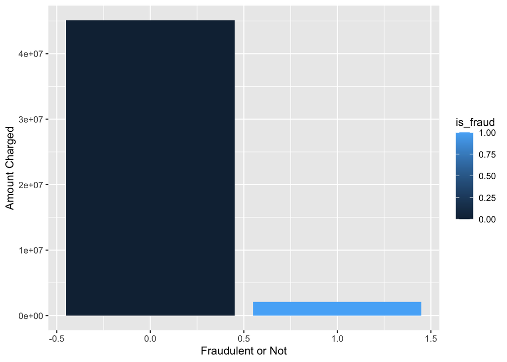

```r
#Overview histogram with both fraudulent and not.

histogram<- card_fraud %>%
  select(is_fraud, amt)

ggplot(histogram)+
  aes(x=is_fraud, y=amt, fill=is_fraud)+
  geom_histogram(stat="Identity") +
  labs(Title = "Distribution of Amounts Charged", x = "Fraudulent or Not", y = "Amount Charged")
```

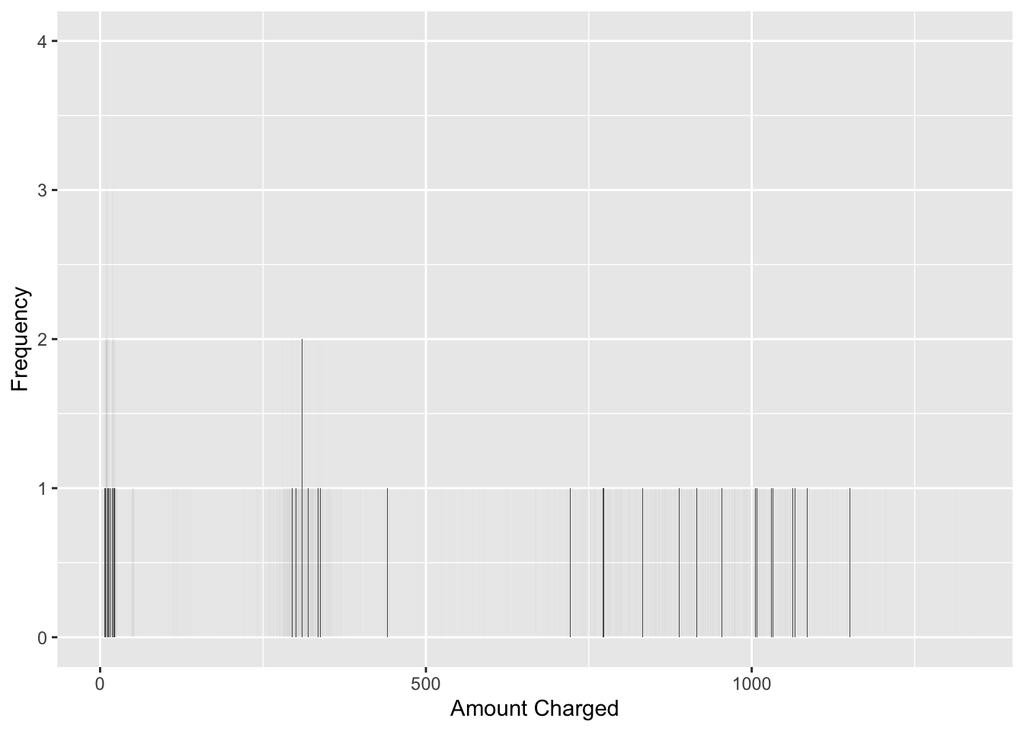

```r
#Histogram with distribution/frequency of each transaction amount for fraudulent transactions:

histogram_fraud <- card_fraud %>%
  filter(is_fraud == 1) %>%
  select(is_fraud, amt) %>%
  count(amt)

ggplot(histogram_fraud)+
  aes(x=amt, y=n)+
  geom_histogram(stat = "Identity")+
  labs(Title = "Distribution of Amounts Charged", x = "Amount Charged", y = "Frequency")
```